# RI Wood Turtle Data

# Introduction

The goal of this project is to analyze telemetry data collected over to 2022 field season on six wood turtles (3 males and 3 females), to look for patterns and differences between their home ranges and how far away the areas they are occupying are from the stream.

## Getting started

Activate necessary packages and clear R’s brain

```r
rm(list = ls())
library(dplyr)
library(ggplot2)
library(here)
library(ggfortify)
library(adehabitatHR)
library(sp)
```

## Pull in the UTM turtle data

```r
UTM_turtles <- read.csv(here("Data", "updated_turtle_locations.csv"))
```

## Pulling in the data

The telemetry data is the first dataset that needs to be pulled in and checked for errors

```r
turtles <- read.csv(here("Data", "RI_turtle_data.csv"), stringsAsFactors = TRUE)
```

## Check out the data

```r
str(turtles) #shows the data frame
```

```
'data.frame':   1023 obs. of  13 variables:
 $ Date       : Factor w/ 153 levels "4/14/2022","4/15/2022",..: 15 16 16 16 17 17 18 19 20 22 ...
 $ Time       : Factor w/ 4 levels "11:00","13:00",..: 3 4 1 3 4 1 1 1 1 1 ...
 $ Latitude   : num  41.6 41.6 41.6 41.6 41.6 ...
 $ Longitude  : num  -71.7 -71.7 -71.7 -71.7 -71.7 ...
 $ Turtle_ID  : Factor w/ 6 levels "L1R2","L1R4",..: 1 1 1 1 1 1 1 1 1 1 ...
 $ Turtle_sex : Factor w/ 2 levels "female","male": 2 2 2 2 2 2 2 2 2 2 ...
 $ Altitude   : num  10.17 3.66 -15.46 4.21 16.19 ...
 $ Duration   : num  22 66 18.3 45 35.7 ...
 $ Temperature: num  26.3 20 24 28.2 20.7 ...
 $ Voltage    : int  0 0 0 0 0 0 0 0 0 0 ...
 $ DOP        : num  2.2 2.1 1.93 2.33 2.33 ...
 $ Satellites : num  5 4.5 4.67 4.33 4.33 ...
 $ EST_Time   : Factor w/ 449 levels "4/14/22 13:00",..: 26 31 28 30 35 32 36 40 44 51 ...
```

Check the column names

```r
names(turtles)
```

```
 [1] "Date"        "Time"        "Latitude"    "Longitude"
 [5] "Turtle_ID"   "Turtle_sex"  "Altitude"    "Duration"
 [9] "Temperature" "Voltage"     "DOP"         "Satellites"
[13] "EST_Time"
```

Check the levels for the columns Turtle_ID and Turtle_sex. There should be six and two levels respectively.

```r
levels(turtles$Turtle_ID)
```

```
[1] "L1R2" "L1R4" "L3R1" "L3R3" "L3R9" "L9R0"
```

```r
levels(turtles$Turtle_sex)
```

```
[1] "female" "male"
```

The Latitudes and Longitudes can be checked for errors by using histograms

First, the latitudes

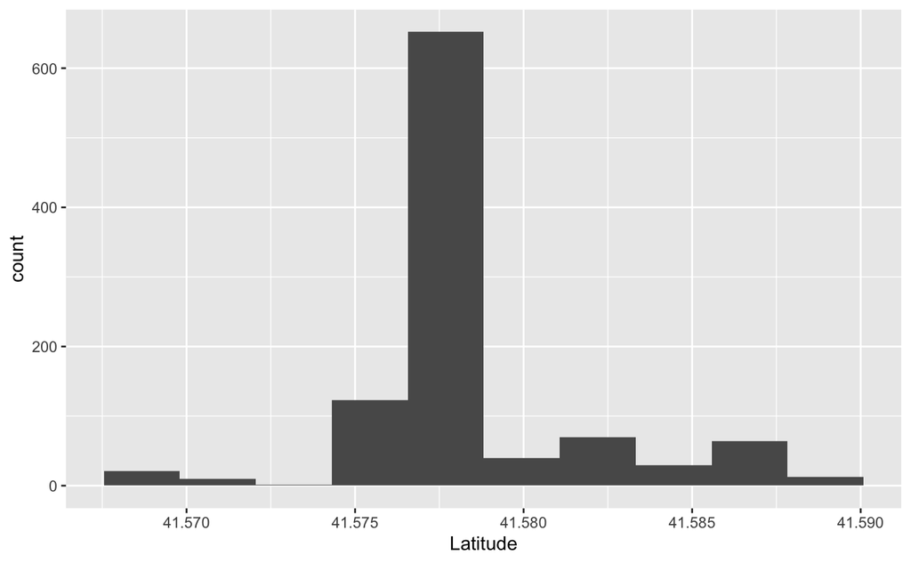

```r
ggplot(turtles, aes(x = Latitude)) +
  geom_histogram(bins = 10)
```

Looks good! Slight variation is expected and the large number of counts in the center is great as well because these turtles all live along the same river.

Now, the longitudes

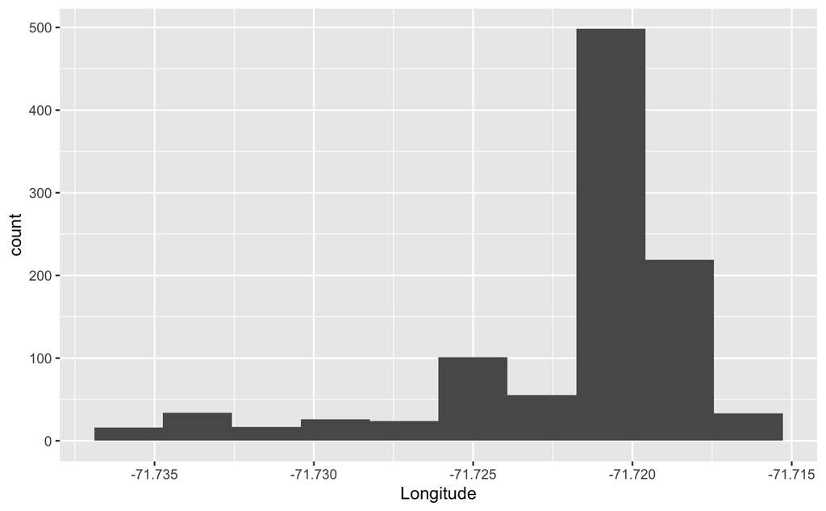

```r
ggplot(turtles, aes(x = Longitude)) +
  geom_histogram(bins = 10)
```

Looks great!

## Calculating Homerange

Before we can calculate the home ranges for each turtle, we need to generate subsets that sort the data by each individual.

```r
L1R2_male <- filter(turtles, Turtle_ID == "L1R2")
L3R1_male <- filter(turtles, Turtle_ID == "L3R1")
L9R0_male <- filter(turtles, Turtle_ID == "L9R0")
L1R4_female <- filter(turtles, Turtle_ID == "L1R4")
L3R3_female <- filter(turtles, Turtle_ID == "L3R3")
L3R9_female <- filter(turtles, Turtle_ID == "L3R9")
```

In order for R to interpret the latitudes and longitudes as coordinates, a matrix needs to be created with the X and Y values for the coordinate locations. Lets work through the entire workflow with L1R2 first

```r
L1R2_latlong <- cbind(L1R2_male$Latitude, L1R2_male$Longitude)
```

Now convert the matrix into spatial points

```r
L1R2_sp <- SpatialPoints(L1R2_latlong)
L1R2_sp
```

```
SpatialPoints:
       coords.x1 coords.x2
  [1,]  41.57883 -71.72012
  [2,]  41.57761 -71.72027
  [3,]  41.57763 -71.72005
  [4,]  41.57789 -71.71999
  [5,]  41.57790 -71.72010
  [6,]  41.57795 -71.72002
  [7,]  41.57751 -71.72012
  [8,]  41.57785 -71.72001
  [9,]  41.57886 -71.72042
 [10,]  41.57845 -71.72031
 [11,]  41.57875 -71.72037
 [12,]  41.57862 -71.72029
 [13,]  41.57857 -71.72028
```

[output cut: 101 more lines]

Now that R recognizes the coordinates for L1R2, we need to use the clusthr() function to implement a single-linkage clustering algorithm

```r
L1R2_clu <- clusthr(L1R2_sp)
class(L1R2_clu)
```

```
[1] "SpatialPolygonsDataFrame"
attr(,"package")
[1] "sp"
```

Plot the results

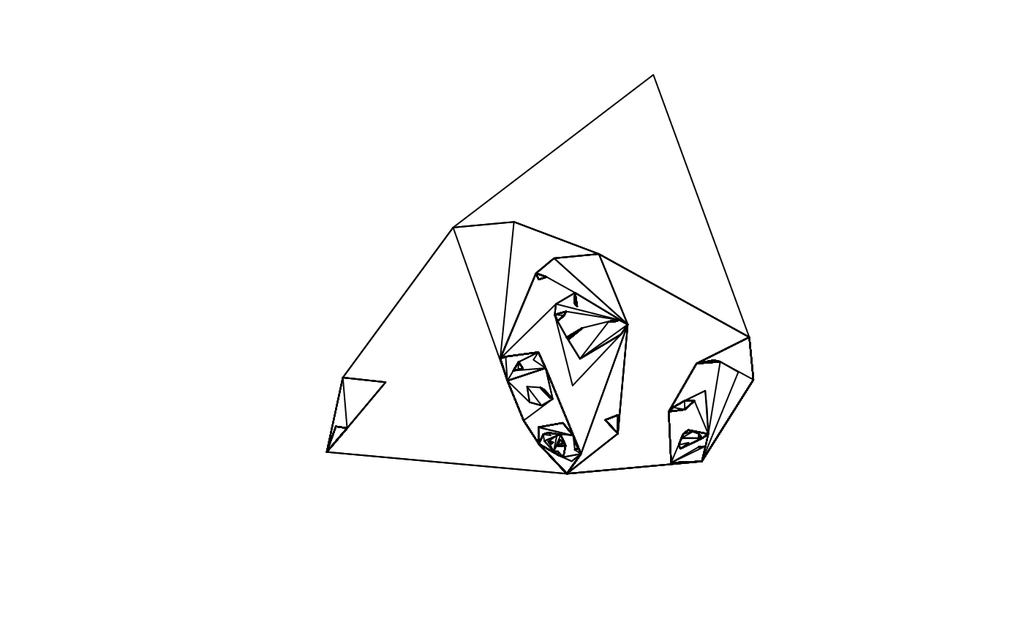

```r
plot(L1R2_clu)
```

Now put together the MCP for L1R2

```r
L1R2_mcp <- mcp(L1R2_sp, percent = 95)
class(L1R2_mcp)
```

```
[1] "SpatialPolygonsDataFrame"
attr(,"package")
[1] "sp"
```

Plot the MCP for L1R2

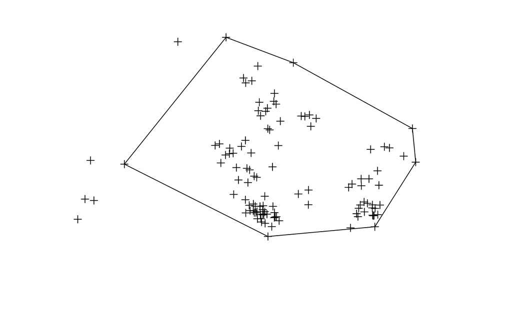

```r
plot(L1R2_mcp)
plot(L1R2_sp, add=TRUE)
```

Now that we know the coding process for generating an MCP, replicate the process with the other individuals.

Create the latlong groupings for the remaining 5 individuals

```r
L1R4_latlong <- cbind(L1R4_female$Latitude, L1R4_female$Longitude)
L3R1_latlong <- cbind(L3R1_male$Latitude, L3R1_male$Longitude)
L3R3_latlong <- cbind(L3R3_female$Latitude, L3R3_female$Longitude)
L3R9_latlong <- cbind(L3R9_female$Latitude, L3R9_female$Longitude)
L9R0_latlong <- cbind(L9R0_male$Latitude, L9R0_male$Longitude)
```

Convert into spatial points

```r
L1R4_sp <- SpatialPoints(L1R4_latlong)
L3R1_sp <- SpatialPoints(L3R1_latlong)
L3R3_sp <- SpatialPoints(L3R3_latlong)
L3R9_sp <- SpatialPoints(L3R9_latlong)
L9R0_sp <- SpatialPoints(L9R0_latlong)
```

Use the clusthr() function to implement a single-linkage clustering algorithm

```r
L1R4_clu <- clusthr(L1R4_sp)
L3R1_clu <- clusthr(L3R1_sp)
L3R3_clu <- clusthr(L3R3_sp)
L3R9_clu <- clusthr(L3R9_sp)
L9R0_clu <- clusthr(L9R0_sp)
```

Let’s plot each of these

L1R4:

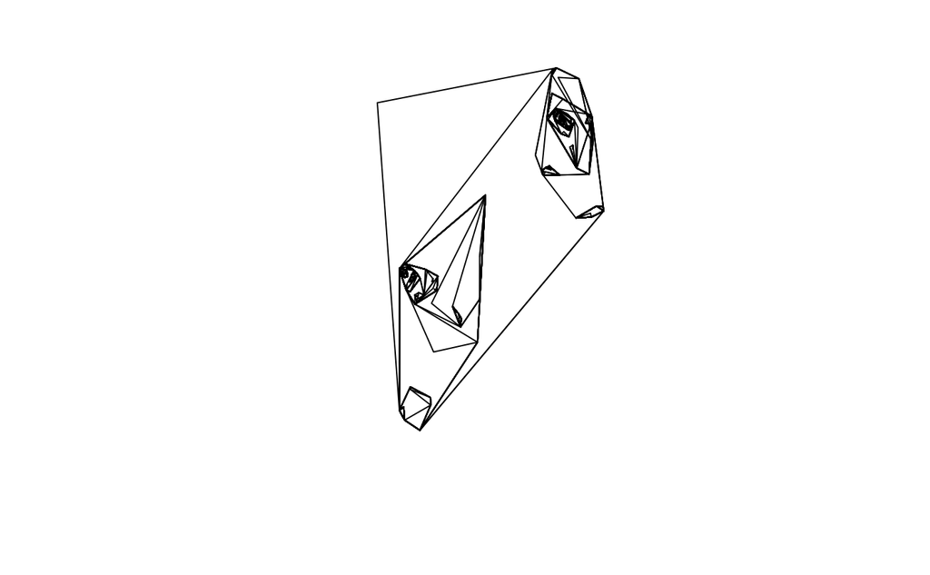

```r
plot(L1R4_clu)
```

L3R1:

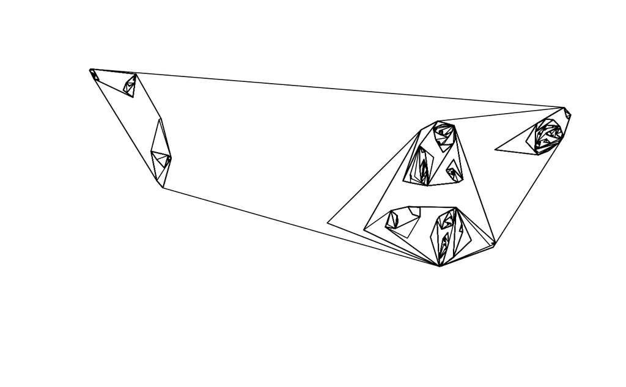

```r
plot(L3R1_clu)
```

L3R3:

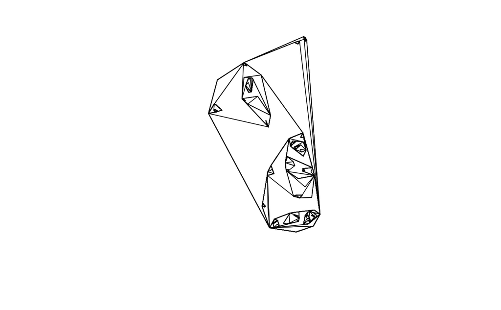

```r
plot(L3R3_clu)
```

L3R9:

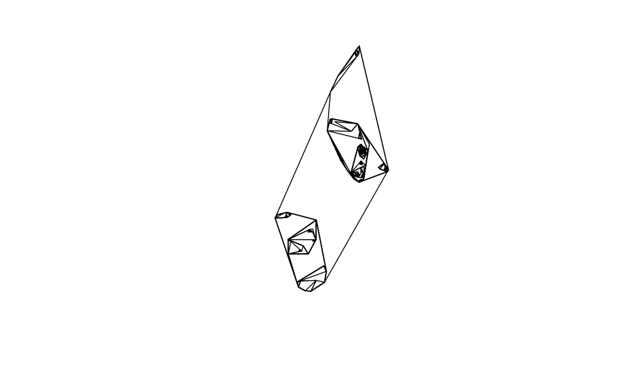

```r
plot(L3R9_clu)
```

L9R0:

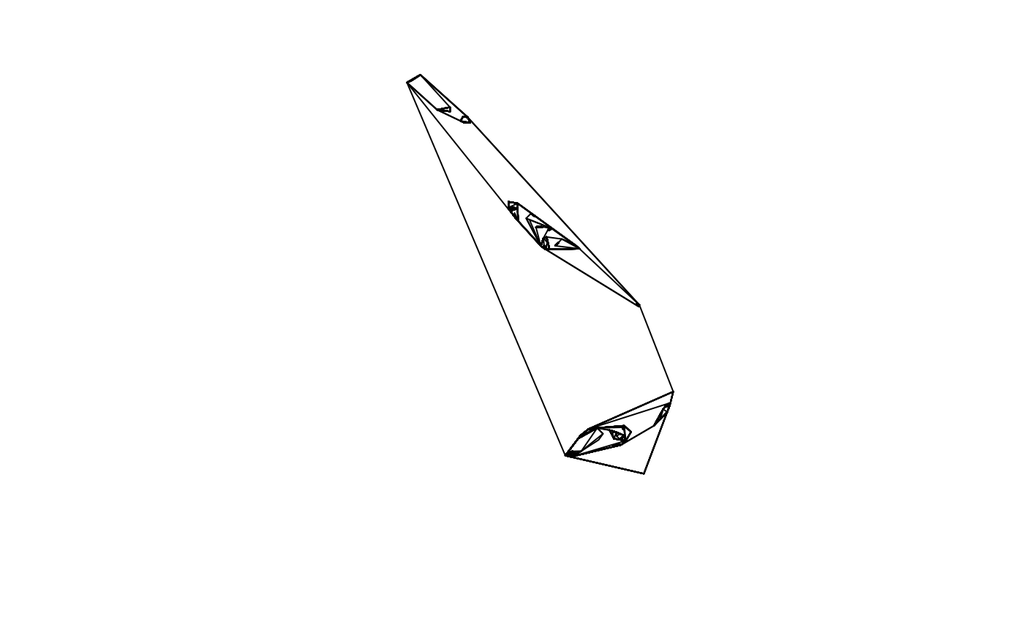

```r
plot(L9R0_clu)
```

Create the MCP for each of the remaining individuals

```r
L1R4_mcp <- mcp(L1R4_sp, percent = 95)
L3R1_mcp <- mcp(L3R1_sp, percent = 95)
L3R3_mcp <- mcp(L3R3_sp, percent = 95)
L3R9_mcp <- mcp(L3R9_sp, percent = 95)
L9R0_mcp <- mcp(L9R0_sp, percent = 95)
```

Plot the MCP for each individual

L1R4:

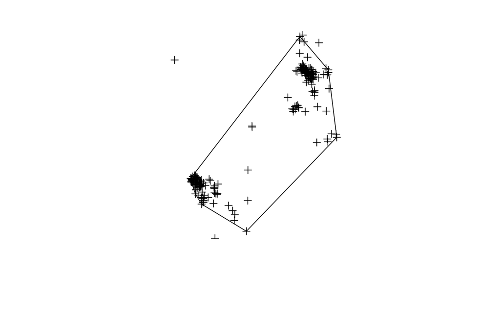

```r
plot(L1R4_mcp)
plot(L1R4_sp, add=TRUE)
```

L3R1:

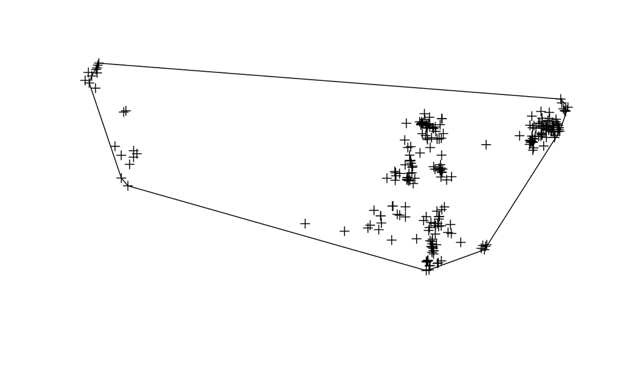

```r
plot(L3R1_mcp)
plot(L3R1_sp, add=TRUE)
```

L3R3:

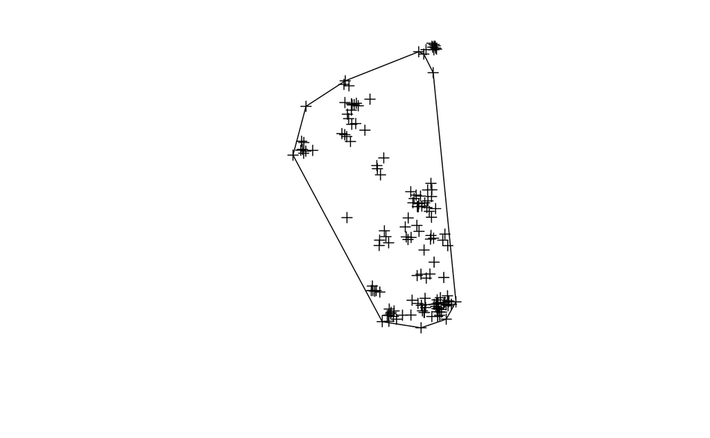

```r
plot(L3R3_mcp)
plot(L3R3_sp, add=TRUE)
```

L3R9:

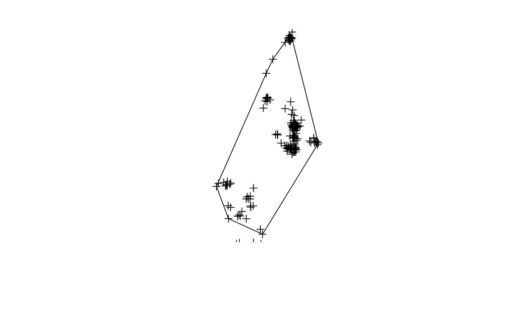

```r
plot(L3R9_mcp)
plot(L3R9_sp, add=TRUE)
```

L9R0:

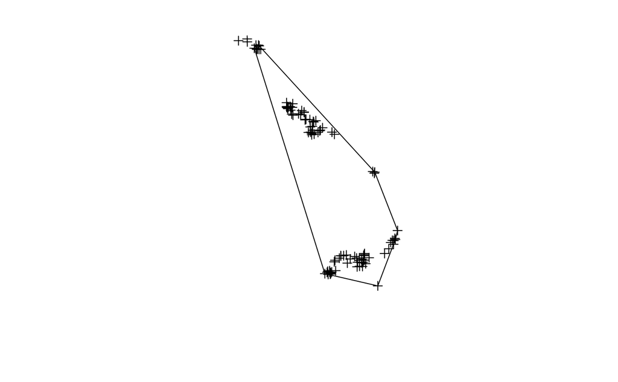

```r
plot(L9R0_mcp)
plot(L9R0_sp, add=TRUE)
```

Check out the area of the MCPs

L1R2:

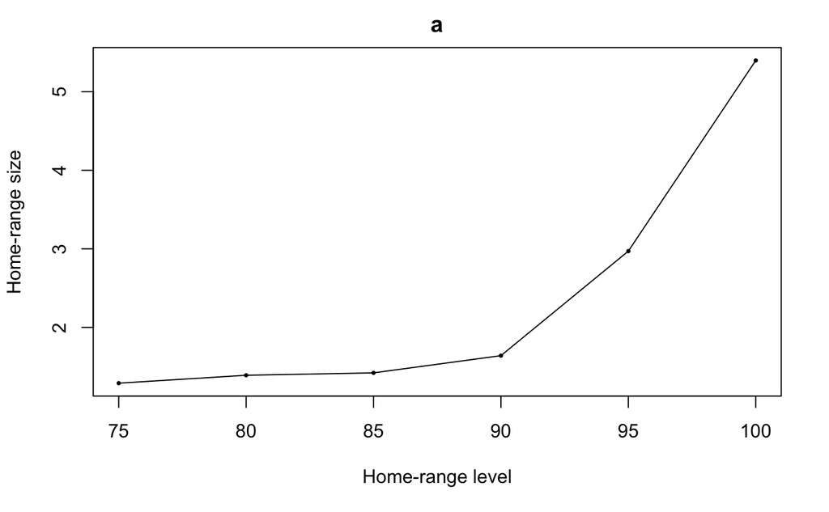

```r
L1R2_area <- mcp.area(L1R2_sp, percent = seq(75,100, by = 5),
                      unin = c("km"),
                      unout = c("m2"), plotit = TRUE) #creates visualization of home range expansion 75% to 100% in increments of 5%
```

```r
L1R2_area #examines dataframe
```

|  | a |
| --- | --- |
| 75 | 1.289921 |
| 80 | 1.390574 |
| 85 | 1.421173 |
| 90 | 1.640376 |
| 95 | 2.971131 |
| 100 | 5.397879 |

L1R4:

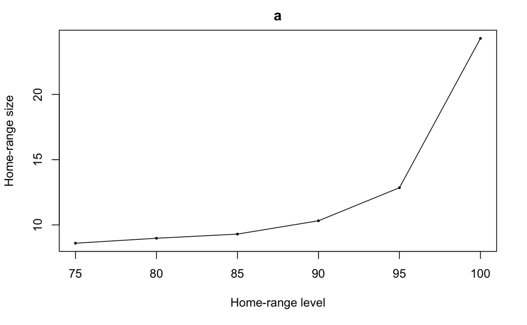

```r
L1R4_area <- mcp.area(L1R4_sp, percent = seq(75,100, by = 5),
          unin = c("km"),
         unout = c("m2"), plotit = TRUE)
```

```r
L1R4_area
```

|  | a |
| --- | --- |
| 75 | 8.597607 |
| 80 | 8.979368 |
| 85 | 9.297067 |
| 90 | 10.316723 |
| 95 | 12.850991 |
| 100 | 24.291068 |

L3R1:

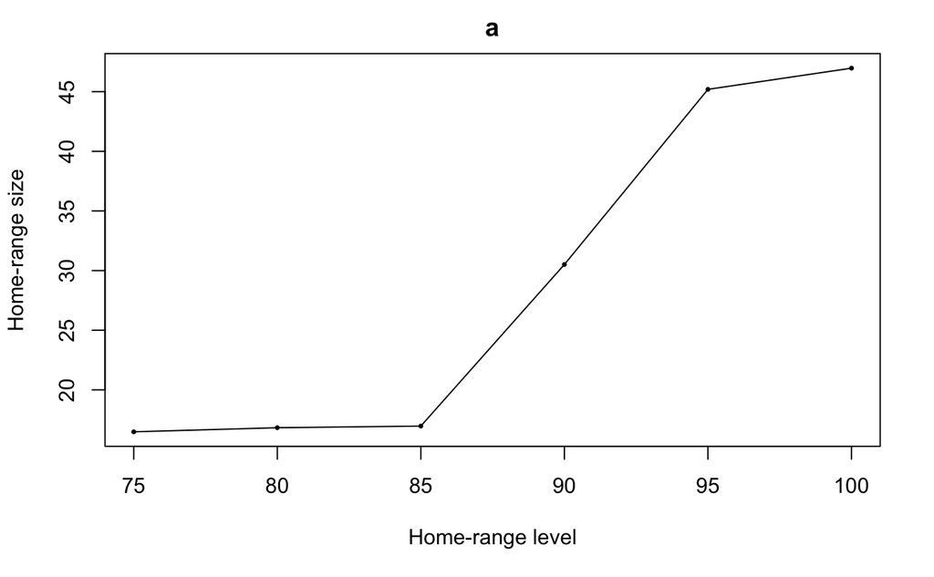

```r
L3R1_area <- mcp.area(L3R1_sp, percent = seq(75,100, by = 5),
          unin = c("km"),
         unout = c("m2"), plotit = TRUE)
```

```r
L3R1_area
```

|  | a |
| --- | --- |
| 75 | 16.48269 |
| 80 | 16.82723 |
| 85 | 16.96457 |
| 90 | 30.50923 |
| 95 | 45.19394 |
| 100 | 46.97073 |

L3R3:

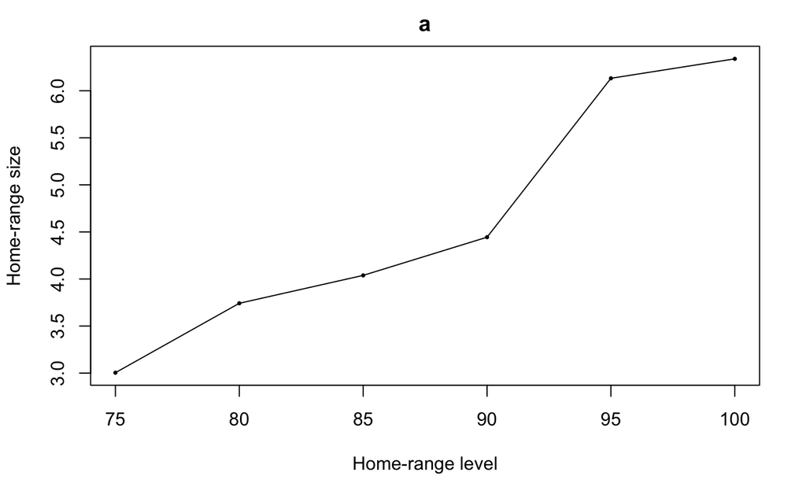

```r
L3R3_area <- mcp.area(L3R3_sp, percent = seq(75,100, by = 5),
          unin = c("km"),
         unout = c("m2"), plotit = TRUE)
```

```r
L3R3_area
```

|  | a |
| --- | --- |
| 75 | 3.004429 |
| 80 | 3.741867 |
| 85 | 4.038390 |
| 90 | 4.444174 |
| 95 | 6.132195 |
| 100 | 6.339094 |

L3R9:

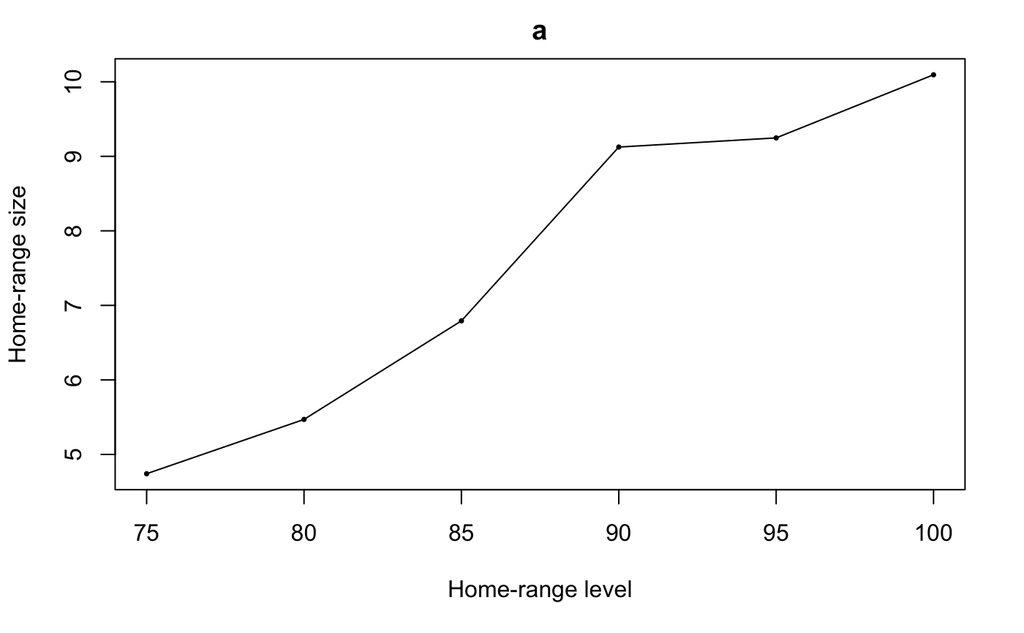

```r
L3R9_area <- mcp.area(L3R9_sp, percent = seq(75,100, by = 5),
          unin = c("km"),
         unout = c("m2"), plotit = TRUE)
```

```r
L3R9_area
```

|  | a |
| --- | --- |
| 75 | 4.741242 |
| 80 | 5.470007 |
| 85 | 6.792250 |
| 90 | 9.124328 |
| 95 | 9.247251 |
| 100 | 10.094231 |

L9R0:

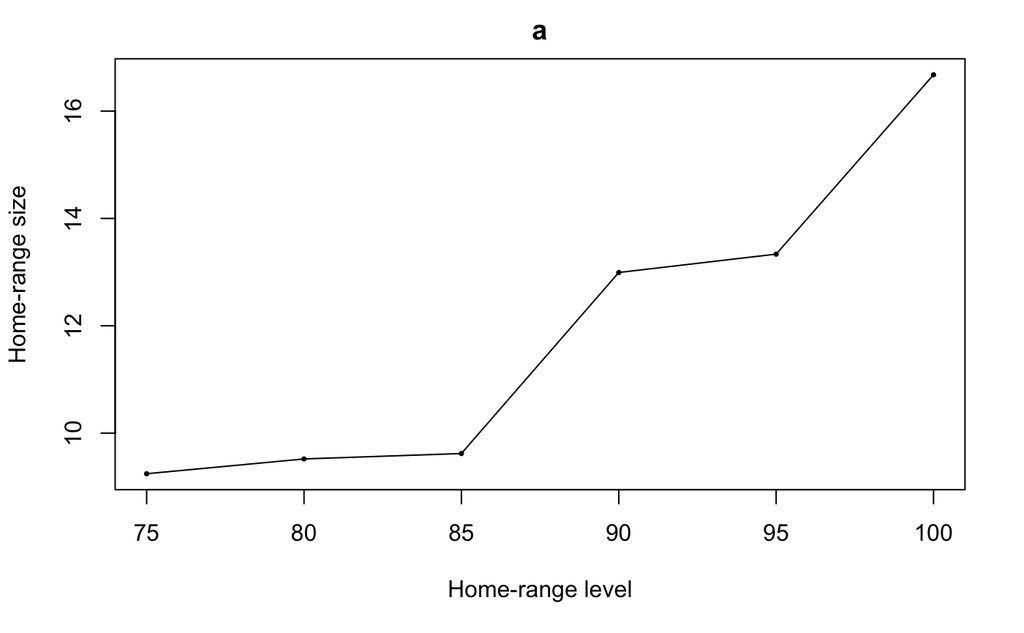

```r
L9R0_area <- mcp.area(L9R0_sp, percent = seq(75,100, by = 5),
          unin = c("km"),
         unout = c("m2"), plotit = TRUE)
```

```r
L9R0_area
```

|  | a |
| --- | --- |
| 75 | 9.243870 |
| 80 | 9.519542 |
| 85 | 9.620217 |
| 90 | 12.992788 |
| 95 | 13.335143 |
| 100 | 16.676472 |

Merge areas into one dataset

```r
areas <- cbind(L1R2_area, L1R4_area, L3R1_area, L3R3_area, L3R9_area, L9R0_area)
colnames(areas) <- c("L1R2", "L1R4", "L3R1", "L3R3", "L3R9", "L9R0")
areas
```

|  | L1R2 | L1R4 | L3R1 | L3R3 | L3R9 | L9R0 |
| --- | --- | --- | --- | --- | --- | --- |
| 75 | 1.289921 | 8.597607 | 16.48269 | 3.004429 | 4.741242 | 9.243870 |
| 80 | 1.390574 | 8.979368 | 16.82723 | 3.741867 | 5.470007 | 9.519542 |
| 85 | 1.421173 | 9.297067 | 16.96457 | 4.038390 | 6.792250 | 9.620217 |
| 90 | 1.640376 | 10.316723 | 30.50923 | 4.444174 | 9.124328 | 12.992788 |
| 95 | 2.971131 | 12.850991 | 45.19394 | 6.132195 | 9.247251 | 13.335143 |
| 100 | 5.397879 | 24.291068 | 46.97073 | 6.339094 | 10.094231 | 16.676472 |

Ok - this is where the capDAP_turtlesDRAFT.Rmd stopped. See that file for comments on the code above this point.

Pivot the data to be long

```r
library(tidyr) #activates package
areas_long <- pivot_longer(areas, cols = L1R2:L9R0, names_to = "Turtle_ID", values_to = "MCP_area")
```

You lost track (label) in the long csv of which mcp each row corresponds to (75,80, 85, 90 etc.). You should probabaly keep track of that.

Export draft as a .csv

```r
write.csv(areas, "C:\\jesiro19\\Home\\Biostats\\CapDAP_turtles\\Code\\MCP_areas.csv", row.names = TRUE)
```

This write.csv, without using the here package, is problematic because it is pointing to your hard drive, not to a relative path within your project folder (which here would allow you to do.)